# Assignment 1

Mouaid Alim

# Dataset Selection

For this project I will be using the GEO dataset with acess number: GSE208637

The original study from Liu et al. (2023) that generated the dataset, focused on understanding the role of CD161-expressing CD8+ T cells in chronic Hepatitis B (HBV) infection. The research aimed to explore their profiles and changes during chronic HBV infection.

The dataset was used in this study to analyze blood and liver tissue samples from chronic HBV patients. Specifically, it involved the characterization of CD161+CD8+ T cells through various methods. The two conditions in the dataset are whether AST>40 or AST<40. The relevance of the AST>40 and AST<40 categories in the study relates to the assessment of liver injury severity in chronic HBV-infected patients. AST (Aspartate Aminotransferase) is a liver enzyme, and its levels in the blood are used as an indicator of liver health. In this context, patients with AST levels greater than 40 units per liter (AST>40) represent a group with more severe liver injury, whereas those with AST levels less than 40 units per liter (AST<40) represent a less severely affected group. This distinction allowed the researchers to investigate how the severity of liver injury in chronic HBV infection influences the behavior and characteristics of CD161+CD8+ T cells.

This dataset involves liver tissues from HBV-infected patients, meeting the requirement for human cell or tissue samples. It compares liver tissues from patients with different severities of liver injury (AST<40 and AST>40). It used next-generation sequencing (NGS) by using the Illumina platform, and had very comprehensive gene coverage. The experiment includes 10 samples with biological replicates for both conditions (4 for AST<40 and 6 for AST>40), suggesting good quality. The dataset was made public in 2023, fitting within the ten-year recency requirement.

This dataset was off interest to me as it is relevant to my area of research. I do clinical research on Liver Transplantation at the Ajmera transplant centre. Which is why when I searched for a dataset in the GEO search bar I wrote Liver Transplantation. This dataset was one of two that were the most recent and it met the requirements, so I selected it.

Below is an image from the Liu et al. (2023) paper showing the difference in tissue from AST<40 patient i.e the patients with less severe liver injury  
and AST>40 patients i.e patients with more severe liver injury. So it shows how the tissue that was used to create out samples would look like. The image was created using the knitr package (Xie (2023)).

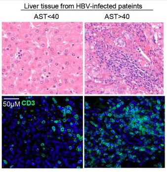

```r
knitr::include_graphics("image.png")
```

# Dataset Info and Download

To get the dataset from geo we use the GEOquery package (Davis (2023)).

```r
# The accession id for the dataset
geo_accession_id <- "GSE208637"

# Inspect the supplementary file for the data
gds <- GEOquery::getGEO(geo_accession_id, GSEMatrix = FALSE )
```

```
## Setting options('download.file.method.GEOquery'='auto')
```

```
## Setting options('GEOquery.inmemory.gpl'=FALSE)
```

```
## Reading file....
```

```
## Parsing....
```

[output not shown]

```
## GPL16791 (1 of 12 entities)
```

```
## GSM6355994 (2 of 12 entities)
```

```
## GSM6355995 (3 of 12 entities)
```

```
## GSM6355996 (4 of 12 entities)
```

```
## GSM6355997 (5 of 12 entities)
```

```
## GSM6355998 (6 of 12 entities)
```

```
## GSM6355999 (7 of 12 entities)
```

```
## GSM6356000 (8 of 12 entities)
```

```
## GSM6356001 (9 of 12 entities)
```

```
## GSM6356002 (10 of 12 entities)
```

```
## GSM6356003 (11 of 12 entities)
```

```r
# Get a summary of how the data was uploaded
gds@header$summary
```

[output not shown]

### Sample data

There are 10 samples in the study, the table below will illustrate the name of each sample and the shortname used to represent it. The kableExtra package was used to visualize the samples (Zhu (2021) ).

```r
# Create the
sample_df <- data.frame(
  GEO_Accession = gds@gsms[["GSM6355994"]]@header[["geo_accession"]],
  Title = gds@gsms[["GSM6355994"]]@header[["title"]],
  Short_Name = gds@gsms[["GSM6355994"]]@header[["description"]],
  stringsAsFactors = FALSE # To keep string data as character type
)

for (row in gds@header[["sample_id"]][2:10]){
  sample_df <- rbind(sample_df, data.frame(
  GEO_Accession = gds@gsms[[ row]]@header[["geo_accession"]],
  Title = gds@gsms[[ row]]@header[["title"]],
  Short_Name = gds@gsms[[ row]]@header[["description"]],
  stringsAsFactors = FALSE # To keep string data as character type
))
}

# Show the different samples and the short forms used to represent them
kableExtra::kable(sample_df, format ="html")
```

| GEO_Accession | Title | Short_Name |
| --- | --- | --- |
| GSM6355994 | L, Liver tissue, HBV infected, AST<40, biol rep1 | L1 |
| GSM6355995 | L, Liver tissue, HBV infected, AST<40, biol rep2 | L2 |
| GSM6355996 | L, Liver tissue, HBV infected, AST<40, biol rep3 | L3 |
| GSM6355997 | L, Liver tissue, HBV infected, AST<40, biol rep4 | L4 |
| GSM6355998 | H, Liver tissue, HBV infected, AST>40, biol rep1 | H1 |
| GSM6355999 | H, Liver tissue, HBV infected, AST>40, biol rep2 | H2 |
| GSM6356000 | H, Liver tissue, HBV infected, AST>40, biol rep3 | H3 |
| GSM6356001 | H, Liver tissue, HBV infected, AST>40, biol rep4 | H4 |
| GSM6356002 | H, Liver tissue, HBV infected, AST>40, biol rep5 | H5 |
| GSM6356003 | H, Liver tissue, HBV infected, AST>40, biol rep6 | H6 |

### Downloading the dataset

From looking at the home page for the dataset, I know that there is only one file and it is the gene counts supplementary file. So what I will do now is get the name of the file, then download the file and ensure that the file is only downloaded again if it is not present

```r
# get the name of the supplementary file
supplmentary_files = GEOquery::getGEOSuppFiles(geo_accession_id, fetch_files = FALSE)
dataset_file_name <- supplmentary_files$fname

# Download the dataset

# save current directory
working_dir <- file.path(getwd())

# checking to see if the dataset file exists already to download file once and
# avoid redownloading
missing_files <- supplmentary_files$fname[!unlist(
  lapply(supplmentary_files$fname, FUN=function(x){
    file.exists( file.path(working_dir, geo_accession_id,x))}))]

# Downlod the file if it has not been downloaded
if (length(missing_files) > 0){
  # Get the dataset
  supp_file = GEOquery::getGEOSuppFiles(GEO = geo_accession_id,
                                        filter_regex = missing_files,
                                        baseDir = working_dir,
                                        fetch_files = TRUE)
}
```

### Load data and inspect it

Now that we have the file downloaded, we load it into a table so we can check it’s dimensions and start working on it.

```r
# Create the relative path for the downloaded dataset file
dataset_path <- paste(working_dir,"/GSE208637/GSE208637_readcounts.txt.gz", sep = "")

# read the dataset into a table
liver_disease_data <- read.table(dataset_path, header = TRUE, check.names = TRUE)

# inspect the dimensions of the dataset to check that the dataset is complete
dim(liver_disease_data)
```

```
## [1] 56275    11
```

```r
# check the first few rows of the dataset
kableExtra::kable(liver_disease_data[1:10,], format ="html")
```

| Geneid | L1 | L2 | L3 | L4 | H1 | H2 | H3 | H4 | H5 | H6 |
| --- | --- | --- | --- | --- | --- | --- | --- | --- | --- | --- |
| 5_8S_rRNA | 0 | 0 | 0 | 0 | 0 | 0 | 0 | 0 | 0 | 0 |
| 5S_rRNA | 0 | 0 | 1 | 0 | 0 | 0 | 0 | 0 | 1 | 0 |
| 7SK | 0 | 2 | 4 | 1 | 2 | 2 | 4 | 0 | 0 | 2 |
| A1BG | 176 | 2999 | 3503 | 3815 | 1530 | 9938 | 2429 | 13692 | 634 | 1791 |
| A1BG-AS1 | 90 | 1442 | 1832 | 2183 | 753 | 4812 | 1079 | 6639 | 285 | 997 |
| A1CF | 662 | 5642 | 6797 | 5401 | 886 | 935 | 426 | 1416 | 691 | 496 |
| A2M | 1564 | 12005 | 6577 | 19880 | 43495 | 48628 | 16009 | 63498 | 15142 | 38681 |
| A2M-AS1 | 142 | 565 | 271 | 398 | 475 | 771 | 232 | 746 | 266 | 411 |
| A2ML1 | 0 | 1 | 2 | 4 | 0 | 4 | 0 | 4 | 10 | 2 |
| A2ML1-AS1 | 2 | 3 | 2 | 0 | 27 | 8 | 7 | 2 | 34 | 21 |

As we can see, we have 4 columns with the column titles going from L1 to L4, and 6 columns with titles going from H1, to H6. This falls under the expectation we had from the description of the dataset’s samples, where 4 samples were indicated to be AST<40, the low AST level group or the group with the less severe liver injury. On the other hand the the 6 samples were indicated to have AST>40, the high AST level group or the group with higher severity of liver injury. Thus the 4 L columns represent the 4 AST<40 samples and the 6 H columns represent the 6 AST>40 samples.

# Dataset Filtering

Now that we loaded in the dataset and check that everything looks good, we are going to filter the dataset. Since we will be using an edgeR workflow or protocol. It is recommended that we filter out gene rows that have less than 1 read per million across as many samples as there are in the condition with the lowest number of replicates. In our case it is the AST<40 or Low condition that has 4 replicates, which is the lowest number of replicates. So 4 is our knockdown number or n = 4 in our knockdown group.

### Creation of Dataset Matrix

The first think we will do is convert our dataset into a matrix, where the gene ids or features are the rownames. This is because all elements in the count matrix need to be integers.

```r
# get the list of gene ids which are in the first column of the dataset
dataset_rownames <- liver_disease_data[,1]

# create a matrix with the count values
dataset_matrix <- as.matrix(liver_disease_data[,2:11])

# set the row names for the matrix as the gene ids
row.names(dataset_matrix) <- dataset_rownames
```

### visualization of pre-filtered data

Here is some some visualizations of the data before filtering. We have a boxplot and a counts density plot. Visualization code was adapted from BCB420 lectures.

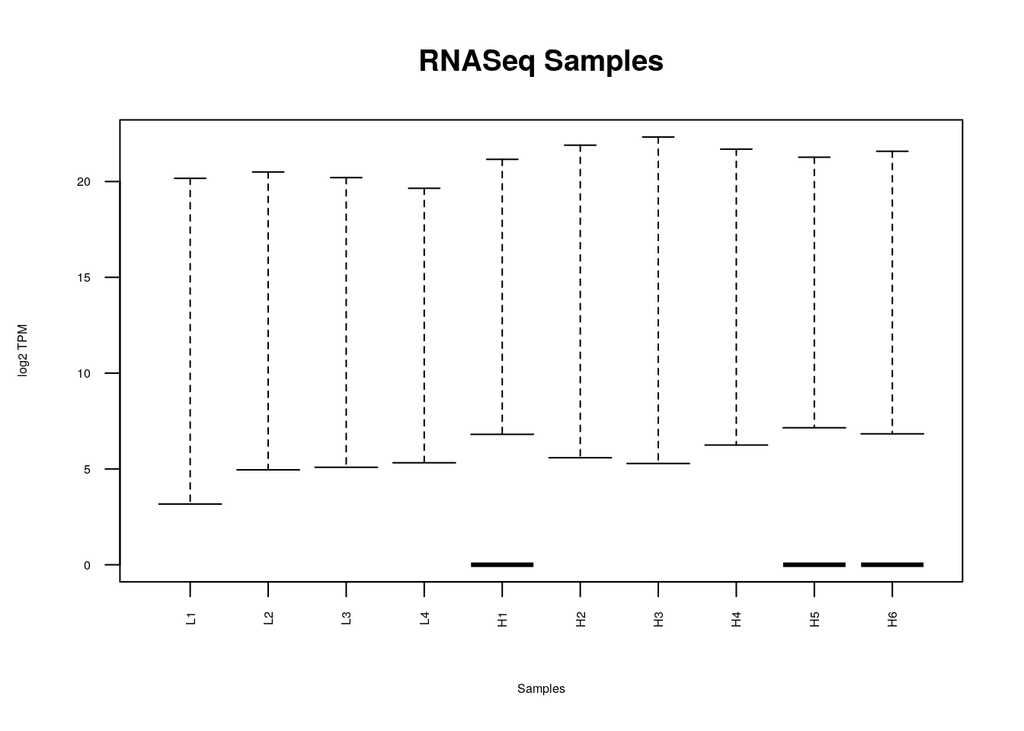

```r
# Boxplot
data2plot <- log2(dataset_matrix)
boxplot(data2plot, xlab = "Samples", ylab = "log2 TPM",
        las = 2, cex = 0.5, cex.lab = 0.5,
        cex.axis = 0.5, main = "RNASeq Samples")

#draw the median on each box plot
abline(h = median(apply(data2plot, 2, median)),
       col = "green", lwd = 0.6, lty = "dashed")
```

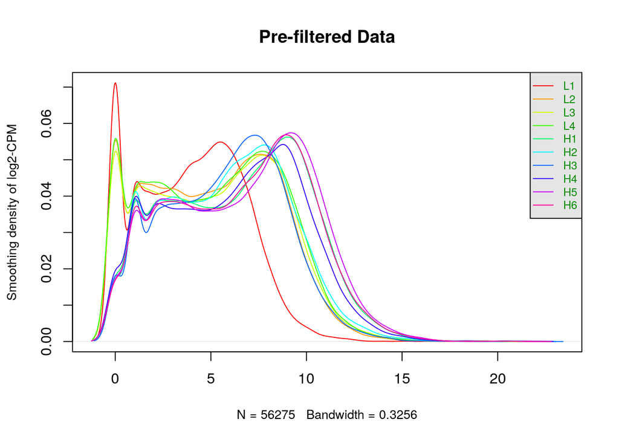

```r
# density plot
counts_density <- apply(log2(dataset_matrix), 2, density)
#calculate the limits across all the samples
xlim <- 0; ylim <- 0
for (i in 1:length(counts_density)) {
xlim <- range(c(xlim, counts_density[[i]]$x));
ylim <- range(c(ylim, counts_density[[i]]$y))
}
cols <- rainbow(length(counts_density))
ltys <- rep(1, length(counts_density))
#plot the first density plot to initialize the plot
plot(counts_density[[1]], xlim=xlim, ylim=ylim, type="n",
ylab="Smoothing density of log2-CPM",
main="Pre-filtered Data", cex.lab = 0.85)
#plot each line
for (i in 1:length(counts_density))
lines(counts_density[[i]], col=cols[i], lty=ltys[i])
#create legend
legend("topright", colnames(data2plot),
col=cols, lty=ltys, cex=0.75,
border ="blue", text.col = "green4",
merge = TRUE, bg = "gray90")
```

### EdgeR based Filtering

Now we filter the data based on the edgeR protocol from the edgeR package (Chen et al. (2023)). Here we use the edgeR cpm function to convert the raw counts to counts per million. Then we only keep the rows with more than 1 count per million in at least 4 samples. Code adapted from the paper by Anders et al. (2013)

```r
# our knockdown number
knockdown_number <- 4

# calculate the counts per million for our data matrix
cpms <- edgeR::cpm(dataset_matrix)

# find the rows we want to keep
keep <- rowSums(cpms > 1) >= knockdown_number

# Create new counts datamatrix containing data after filtering
counts <- dataset_matrix[keep,]

# inspect the new dimension of the data
dim(counts)
```

```
## [1] 16697    10
```

So we are left with 16697 genes after filtering, so around 40,000 genes were filtered out

### Checking for Duplicates

```r
# check if there are any duplicates
print(any(duplicated(names(counts))))
```

```
## [1] FALSE
```

### Post-filtering Visualization

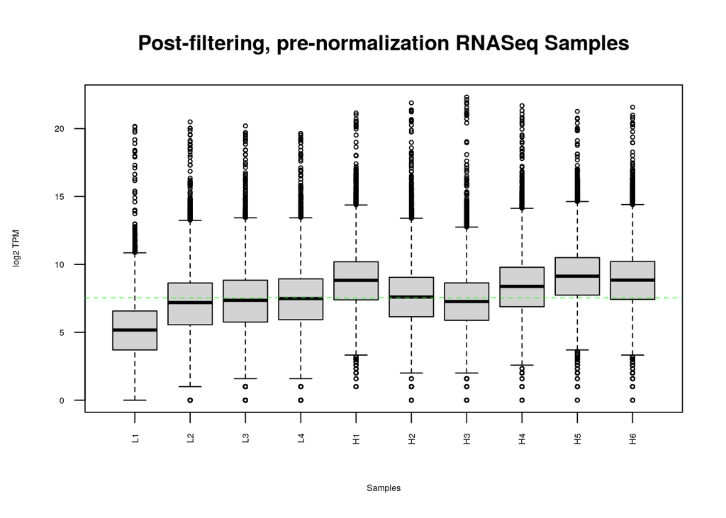

```r
# Boxplot
data2plot <- log2(counts)
boxplot(data2plot, xlab = "Samples", ylab = "log2 TPM",
        las = 2, cex = 0.5, cex.lab = 0.5,
        cex.axis = 0.5, main = "Post-filtering, pre-normalization RNASeq Samples")

#draw the median on each box plot
abline(h = median(apply(data2plot, 2, median)),
       col = "green", lwd = 0.6, lty = "dashed")
```

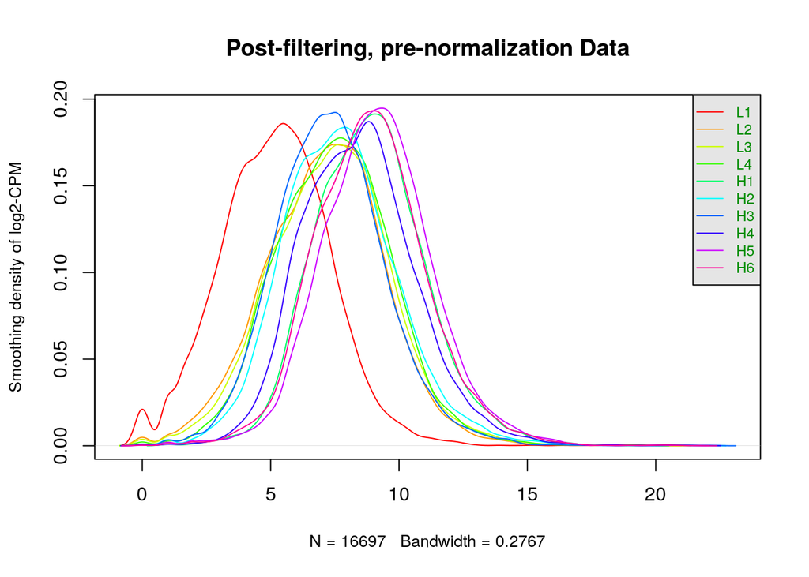

```r
# density plot
counts_density <- apply(log2(counts), 2, density)
#calculate the limits across all the samples
xlim <- 0; ylim <- 0
for (i in 1:length(counts_density)) {
xlim <- range(c(xlim, counts_density[[i]]$x));
ylim <- range(c(ylim, counts_density[[i]]$y))
}
cols <- rainbow(length(counts_density))
ltys <- rep(1, length(counts_density))
#plot the first density plot to initialize the plot
plot(counts_density[[1]], xlim=xlim, ylim=ylim, type="n",
ylab="Smoothing density of log2-CPM",
main="Post-filtering, pre-normalization Data", cex.lab = 0.85)
#plot each line
for (i in 1:length(counts_density))
lines(counts_density[[i]], col=cols[i], lty=ltys[i])
#create legend
legend("topright", colnames(data2plot),
col=cols, lty=ltys, cex=0.75,
border ="blue", text.col = "green4",
merge = TRUE, bg = "gray90")
```

# HGNC Mapping

By manual inspection, I see that most the genes in my dataset are already in the HGNC identifier format. So what I will do now is use the HGNChelper package (Waldron and Riester (2019)). This package will take the list of genes in my dataset and return whether the symbol is HGNC approved. If not it will let me know and provide the HGNC approved symbol for that gene if it finds it.

### Check HGNC mapping

```r
# install HGNChelper package if not installed
if (!requireNamespace('HGNChelper', quietly = TRUE)) {
    install.packages('HGNChelper')
}

# get the gene names from the count matrix rownames
filtered_ds_rownames <- row.names(counts)

# Check if the gene names in my dataset are HGNC approved
checked_hgnc_symbols <- HGNChelper::checkGeneSymbols(filtered_ds_rownames)
```

```
## Maps last updated on: Thu Oct 24 12:31:05 2019
```

```r
not_approved_genes <- checked_hgnc_symbols[checked_hgnc_symbols$Approved == FALSE,]

# view the number of genes with non HGNC approved names
dim(not_approved_genes)
```

```
## [1] 2505    3
```

```r
# View what the symbols table looks like for the non-approved genes
head(not_approved_genes)
```

```
##                       x Approved Suggested.Symbol
## 13                AAED1    FALSE           PRXL2C
## 19                 AARS    FALSE            AARS1
## 29   ABC12-49244600F4.4    FALSE             <NA>
## 30  ABC13-47488600E17.1    FALSE             <NA>
## 106          AC000032.2    FALSE             <NA>
## 107         AC000068.10    FALSE             <NA>
```

### Replace Gene Names

For gene symbols that have not been approved, some of them have a suggested replacement symbol while most don’t. So the next step will be to replace the non approved symbols that have a replacement.

```r
# get only the  non-approved genes with a suggested replacement sumbol
rp_not_approved_genes <- checked_hgnc_symbols[checked_hgnc_symbols$Approved == FALSE &
                                                (!is.na(checked_hgnc_symbols$Suggested.Symbol)),]
# keep only the column with the original symbol and replacement symbol
rp_not_approved_genes <- rp_not_approved_genes[, c(1,3)]

# Get the number of genes with a replacement
dim(rp_not_approved_genes)
```

```
## [1] 475   2
```

```r
# Loop through each row of 'rp_not_approved_genes'
for(i in 1:nrow(rp_not_approved_genes)) {
  # Get the original gene name and the replacement gene name
  original_gene_name <- rp_not_approved_genes[i, 1]
  replacement_gene_name <- rp_not_approved_genes[i, 2]

  # Find the index of the original gene name in the row names of 'counts'
  gene_index <- which(rownames(counts) == original_gene_name)

  # Replace the original gene name with the replacement gene name in 'counts'
  if(length(gene_index) > 0) { # Only replace if the original gene name is found
    rownames(counts)[gene_index] <- replacement_gene_name
  }
}

# check if the replacement was successful
all(rp_not_approved_genes$Suggested.Symbol %in% rownames(counts))
```

```
## [1] TRUE
```

As we can see all genes with a possible HGNC replacement were replaced

### Final Coverage

So we replaced 475 genes with an HGNC mapping, leaving us with 2030 unmapped genes. These genes will be kept in the dataset as many are LOC genes which the prof suggested we keep even though they might be lost in downstream analysis. So the final overall coverage of our dataset is 16697 genes

# Data Normalization

### Normalization Method Selection

For normalization, I have gone through the paper by Evans, Hardin, and Stoebel (2018) as well as the paper by Stark, Grzelak, and Hadfield (2019) in order to understand normalization, the underlying assumptions and the method I will be going with.

I will be going with the Trimmed Mean of M-values normalization method. There are two reasons for choosing this method. The first is that for most normalization methods like RPKM and others, the two assumption are that across replicate groups expression levels stay the same and that there is not a significant difference in mRNA levels between sample groups. From my data visualizations, it does not seem that expression levels stay the same between replicates, and I’m not sure if mRNA levels stay close between groups. However, TMM has the ability to compensate a bit when the assumptions are not met. The second reason is that I am using a edgeR protocol for my development which uses TMM by default.

### Carried out Normalization

Below we carry out the normalization. The code used is sampled from the “Count-based differential expression analysis of RNA sequencing data using R and Bioconductor” paper

```r
# create edgeR DGElist datatype of our data
edge_list <- edgeR::DGEList(counts = counts, group = colnames(counts))

# calculate the normalization factors
estimated_norm_factors = edgeR::calcNormFactors(edge_list)
```

### MDS Plot

Now to view the relationship between the different samples we will plot a multidimensional scaling (MDS) plot from the limma package. The plot will show us how similar or dissimilar the samples are. The MDS plot was plotted using the limma package (Smyth et al. (2023)).

[figure not shown]

```r
limma::plotMDS(estimated_norm_factors, labels = colnames(counts),
        col = c("darkgreen", "darkgreen", "darkgreen", "darkgreen", "darkgreen", "darkgreen", "blue", "blue", "blue", "blue")[factor(colnames(counts))])

legend("topright",
legend=levels(factor(c("AST>40 (High)", "AST<40 (Low)"))),
pch=c(1), col=
c("darkgreen", "blue"),title="Class",
bty = 'n', cex = 0.75)
```

### Normalized Counts and plots

Now that we have the normalized factors, we can get the normalized counts and plot them

```r
normalized_counts <- edgeR::cpm(estimated_norm_factors)
```

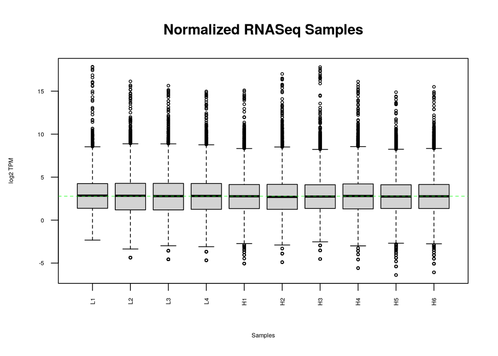

```r
# Boxplot of the normalized data
data2plot <- log2(normalized_counts)
boxplot(data2plot, xlab = "Samples", ylab = "log2 TPM",
        las = 2, cex = 0.5, cex.lab = 0.5,
        cex.axis = 0.5, main = "Normalized RNASeq Samples")

#draw the median on each box plot
abline(h = median(apply(data2plot, 2, median)),
       col = "green", lwd = 0.6, lty = "dashed")
```

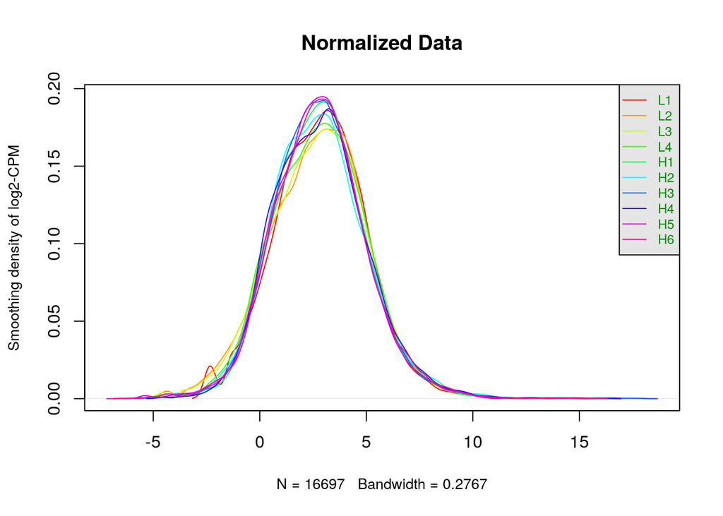

```r
# Density plot of the normalized data
counts_density <- apply(log2(normalized_counts), 2, density)
# calculate the limits across all the samples
xlim <- 0; ylim <- 0
for (i in 1:length(counts_density)) {
xlim <- range(c(xlim, counts_density[[i]]$x));
ylim <- range(c(ylim, counts_density[[i]]$y))
}
cols <- rainbow(length(counts_density))
ltys <- rep(1, length(counts_density))
#plot the first density plot to initialize the plot
plot(counts_density[[1]], xlim=xlim, ylim=ylim, type="n",
ylab="Smoothing density of log2-CPM",
main="Normalized Data", cex.lab = 0.85)
#plot each line
for (i in 1:length(counts_density))
lines(counts_density[[i]], col=cols[i], lty=ltys[i])
#create legend
legend("topright", colnames(data2plot),
col=cols, lty=ltys, cex=0.75,
border ="blue", text.col = "green4",
merge = TRUE, bg = "gray90")
```

# Dispesion Plots

Now that we normalized the data, we will plot the dispersion plots. Dispersion shows us how differing the variance and the mean are. This code was adapted from the normalizing our dataset BCB420 lecture.

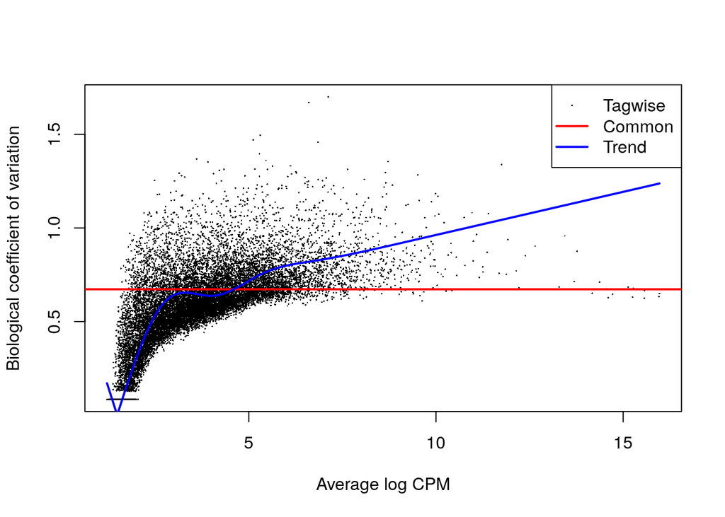

```r
dispersion_edge_list <- edgeR::DGEList(counts = normalized_counts, genes = rownames(normalized_counts))

# use the edgeR package to estimate dispersion
estimated_dispersion <- edgeR::estimateCommonDisp(dispersion_edge_list)
estimated_dispersion <- edgeR::estimateTagwiseDisp(estimated_dispersion)
estimated_dispersion <- edgeR::estimateTrendedDisp(estimated_dispersion)

# Plot the dispersion
design_m <- model.matrix(~colnames(counts))
edgeR::plotBCV(estimated_dispersion, design=design_m, col.tagwise = "black",col.common = "red")
```

Now we plot the relationship between the mean and the variance of our count data. The function fits a model on the data depending on the nature of the count data.

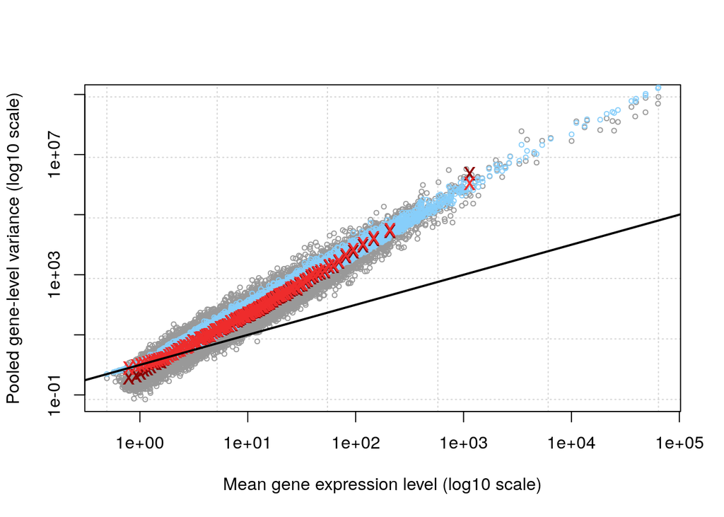

```r
# Plot Mean Variance
edgeR::plotMeanVar(estimated_dispersion, show.raw.vars = TRUE, show.tagwise.vars=TRUE,
            show.ave.raw.vars = TRUE, NBline=FALSE,
            show.binned.common.disp.vars = TRUE)
```

# Outliers

As we can see from our normalized data boxplots, most of our samples have outliers. However, after consideration I will not be removing any outliers. As per the stack exchange thread that was shared in the assignment page, I do not have any information that indicates that the outliers were a result of measurement errors and so they will be kept Egon (2016).

# References

Anders, Simon, Davis J McCarthy, Yunshun Chen, Michal Okoniewski, Gordon K Smyth, Wolfgang Huber, and Mark D Robinson. 2013. “Count-Based Differential Expression Analysis of RNA Sequencing Data Using r and Bioconductor.” *Nature Protocols* 8 (9): 1765–86.

Chen, Yunshun, Aaron TL Lun, Davis J McCarthy, Lizhong Chen, Matthew E Ritchie, Belinda Phipson, Yifang Hu, Xiaobei Zhou, Mark D Robinson, and Gordon K Smyth. 2023. *edgeR: Empirical Analysis of Digital Gene Expression Data in r*. https://doi.org/10.18129/B9.bioc.edgeR.

Davis, Sean. 2023. *GEOquery: Get Data from NCBI Gene Expression Omnibus (GEO)*. https://doi.org/10.18129/B9.bioc.GEOquery.

Egon. 2016. “Is It OK to Remove Outliers from Data?” *Cross Validated*. https://stats.stackexchange.com/questions/200534/is-it-ok-to-remove-outliers-from-data/200923.

Evans, Ciaran, Johanna Hardin, and Daniel M Stoebel. 2018. “Selecting Between-Sample RNA-Seq Normalization Methods from the Perspective of Their Assumptions.” *Briefings in Bioinformatics* 19 (5): 776–92.

Liu, Yu, Wei Wang, Peng Zhu, Xue Cheng, Mi Wu, Haoquan Zhang, Yiqing Chen, et al. 2023. “Increased Non-MAIT CD161+ CD8+ t Cells Display Pathogenic Potential in Chronic HBV Infection.” *Cellular and Molecular Gastroenterology and Hepatology* 15 (5): 1181–98.

Smyth, Gordon, Yifang Hu, Matthew Ritchie, Jeremy Silver, James Wettenhall, Davis McCarthy, Di Wu, et al. 2023. *Limma: Linear Models for Microarray Data*. https://doi.org/10.18129/B9.bioc.limma.

Stark, Rory, Marta Grzelak, and James Hadfield. 2019. “RNA Sequencing: The Teenage Years.” *Nature Reviews Genetics* 20 (11): 631–56.

Waldron, Levi, and Markus Riester. 2019. *HGNChelper: Identify and Correct Invalid HGNC Human Gene Symbols and MGI Mouse Gene Symbols*. https://github.com/waldronlab/HGNChelper.

Xie, Yihui. 2023. *Knitr: A General-Purpose Package for Dynamic Report Generation in r*. https://yihui.org/knitr/.

Zhu, Hao. 2021. *kableExtra: Construct Complex Table with Kable and Pipe Syntax*. http://haozhu233.github.io/kableExtra/.